# WGCNA step_by_step

2023-03-31

## Background

This document is based on “I. Network analysis of liver expression data from female mice: finding modules related to body weight” at the below link.

https://horvath.genetics.ucla.edu/html/CoexpressionNetwork/Rpackages/WGCNA/Tutorials/index.html

It has been adapted to use data generated in this lab for the example as well as other edits where deemed appropriate.

## Load data

```r
t1 <- Sys.time()
expData <- read.table(file = "W103first200.tsv", header = TRUE, sep  ="\t")
expData[1:3, 1:8]
```

```
##           ID           p2         q2         r2      X1.1      X1.2      X1.3
## 1 W103_g1.t1 0.4660834842 0.74101167 -0.7456181  76.81818  89.37500  82.10526
## 2 W103_g2.t1 0.4016089202 0.68937496  0.8602722 137.87879 130.00000 137.81955
## 3 W103_g3.t1 0.0003178123 0.08145604  4.4969571  41.36364  61.38889  54.73684
##        X1.4
## 1  71.11111
## 2 131.11111
## 3  44.44444
```

```r
#nrow(expData)
#ncol(expData) - 4

datExpr <- expData[, -c(1:4)]
expData <- expData[, 1:4]
#expData[1:3, ]

#names(datExpr) <- paste("Sample", 1:ncol(datExpr), sep  ="")
names(datExpr) <- paste("Sample", sub("^X", "", colnames(datExpr)), sep = "")
rownames(datExpr) <- expData$ID
datExpr <- t(datExpr)
```

Data should be a data.frame where rows are samples and columns are genes. Row names are samples names and column names are gene names.

```r
knitr::kable(datExpr[1:3, 1:6], caption = "**Table 1.**")
```

**Table 1.**

|  | W103_g1.t1 | W103_g2.t1 | W103_g3.t1 | W103_g4.t1 | W103_g5.t1 | W103_g6.t1 |
| --- | --- | --- | --- | --- | --- | --- |
| Sample1.1 | 76.81818 | 137.8788 | 41.36364 | 70.90909 | 210.7576 | 291.5152 |
| Sample1.2 | 89.37500 | 130.0000 | 61.38889 | 77.63889 | 272.6389 | 343.9583 |
| Sample1.3 | 82.10526 | 137.8195 | 54.73684 | 86.01504 | 287.3684 | 379.2481 |

## Normalization notes

```
colSums(y1);
m1 = apply(y1, 2, median);
hist(y1[,1]);
mm1 = median(m1);
nf0.1 =  m1/mm1;
```

```
nf1 = nf0.1;
yn1 = t(t(y1) / nf1);
apply(yn1, 2, median)
```

## Data overview

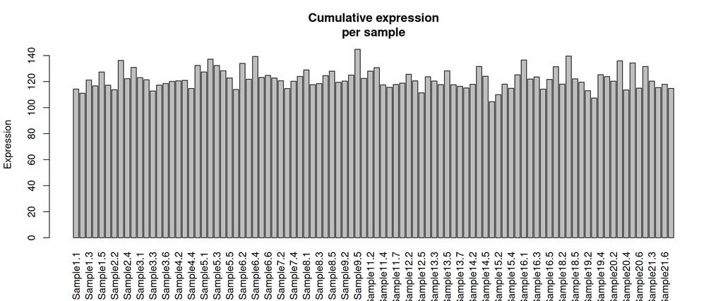

**Figure 1.**

```r
# barplot(rowSums(datExpr), las = 3)
barplot(apply(datExpr, MARGIN = 1, median), las = 3)
title( main = "Cumulative expression\nper sample" )
title( ylab = "Expression" )
```

```r
sort(rowSums(datExpr))[1:10]
```

```
## Sample12.6 Sample15.2 Sample15.5 Sample15.3 Sample15.4  Sample1.1 Sample15.1
##   58986.18   59681.06   59724.57   59891.28   59952.39   59967.42   60022.73
## Sample12.1 Sample20.6 Sample20.2
##   60029.64   60053.16   60191.94
```

```r
sort(rowSums(datExpr), decreasing = TRUE)[1:10]
```

```
## Sample11.2 Sample18.4 Sample16.1 Sample11.5 Sample11.7  Sample3.2 Sample11.3
##   93491.44   90971.11   89228.93   88325.07   88178.62   86717.44   84697.07
##  Sample9.5  Sample5.2  Sample5.3
##   84461.59   83200.00   80117.14
```

Dependent variable.

```r
phenos <- read.table("Ratios.tsv", header = TRUE, sep = "\t", row.names = 1)
names(phenos) <- paste("Sample", sub("^X", "", colnames(phenos)), sep  ="")
#names(phenos) <- paste("Sample", 1:ncol(phenos), sep  ="")
phenos <- unlist(phenos[1,])
phenos[1:6]
```

```
## Sample1.1 Sample1.2 Sample1.3 Sample1.4 Sample1.5 Sample2.1
##  234.0793  195.9582  196.8333  264.3481  290.8373  173.4265
```

```r
#ncol(phenos)
length(phenos)
```

```
## [1] 94
```

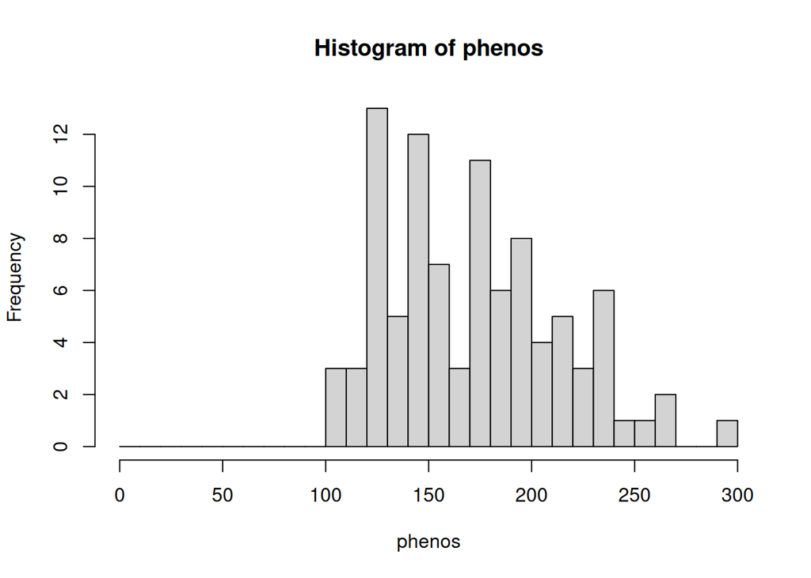

```r
hist(phenos, breaks = seq(0, 300, by = 10))
```

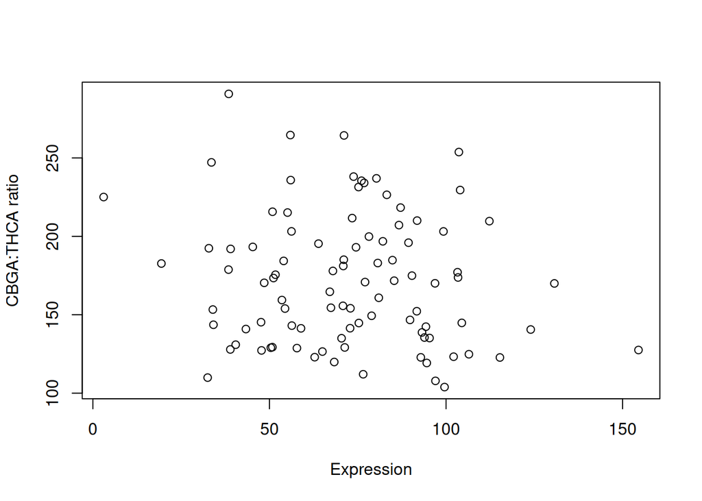

**Figure 2.** No correlation among expression and CBDA:THCA ratio.

```r
plot( x = datExpr[, 1], y = phenos, xlab = "Expression", ylab = "CBGA:THCA ratio")
```

```r
cor.test( x = datExpr[, 1], y = phenos)
```

```
##
##  Pearson's product-moment correlation
##
## data:  datExpr[, 1] and phenos
## t = -1.3073, df = 92, p-value = 0.1944
## alternative hypothesis: true correlation is not equal to 0
## 95 percent confidence interval:
##  -0.32867422  0.06946685
## sample estimates:
##       cor
## -0.135051
```

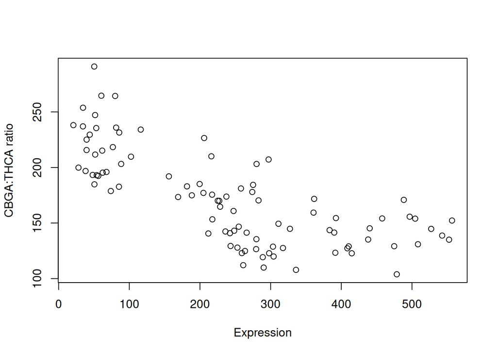

**Figure 3.** Negative correlation among expression and CBDA:THCA ratio.

```r
plot( x = datExpr[, 201], y = phenos, xlab = "Expression", ylab = "CBGA:THCA ratio")
```

```r
cor.test( x = datExpr[, 201], y = phenos)
```

```
##
##  Pearson's product-moment correlation
##
## data:  datExpr[, 201] and phenos
## t = -10.306, df = 92, p-value < 2.2e-16
## alternative hypothesis: true correlation is not equal to 0
## 95 percent confidence interval:
##  -0.8139232 -0.6216094
## sample estimates:
##        cor
## -0.7320284
```

## WGCNA

```r
#library(DESeq2)
library(WGCNA)
#library(dplyr)
#library(readr)
```

## Step-by-step construction of the gene network and identification of modules

```
## ..connectivity..
## ..matrix multiplication (system BLAS)..
## ..normalization..
## ..done.
```

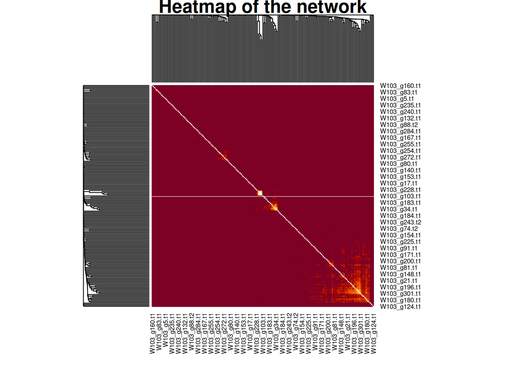

```r
#plotNetworkHeatmap(datExpr, plotGenes = colnames(datExpr)[1:20])
plotNetworkHeatmap(datExpr, plotGenes = colnames(datExpr))
```

```r
# Choose a set of soft-thresholding powers
powers = c(c(1:10), seq(from = 12, to=20, by=2))
# Call the network topology analysis function
enableWGCNAThreads(nThreads = 2)
```

```
## Allowing parallel execution with up to 2 working processes.
```

```r
sft = pickSoftThreshold(datExpr, powerVector = powers, verbose = 5)
```

```
## pickSoftThreshold: will use block size 205.
##  pickSoftThreshold: calculating connectivity for given powers...
##    ..working on genes 1 through 205 of 205
##    Power SFT.R.sq slope truncated.R.sq  mean.k. median.k. max.k.
## 1      1    0.809 -1.14         0.7690 34.20000  3.16e+01 61.600
## 2      2    0.916 -1.05         0.8920  9.78000  7.29e+00 27.200
## 3      3    0.949 -1.13         0.9350  3.75000  2.23e+00 15.100
## 4      4    0.953 -1.15         0.9500  1.73000  7.77e-01  9.340
## 5      5    0.903 -1.26         0.9060  0.90500  3.10e-01  6.200
## 6      6    0.895 -1.26         0.9080  0.51500  1.26e-01  4.310
## 7      7    0.918 -1.30         0.9340  0.31200  6.01e-02  3.110
## 8      8    0.219 -2.20         0.0356  0.19900  2.83e-02  2.300
## 9      9    0.228 -2.12         0.0573  0.13200  1.41e-02  1.730
## 10    10    0.228 -2.04         0.0616  0.09030  7.22e-03  1.330
## 11    12    0.260 -2.07         0.1750  0.04580  1.74e-03  0.819
## 12    14    0.198 -2.30        -0.0187  0.02510  4.17e-04  0.526
## 13    16    0.255 -2.82         0.0856  0.01470  1.03e-04  0.348
## 14    18    0.260 -1.83         0.1650  0.00893  2.71e-05  0.236
## 15    20    0.258 -1.77         0.1540  0.00563  7.43e-06  0.162
```

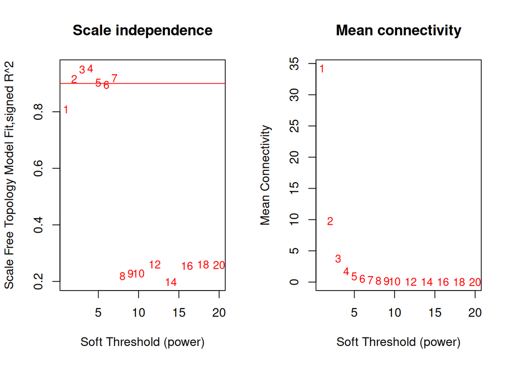

```r
# Plot the results:
#sizeGrWindow(9, 5)
par(mfrow = c(1,2))
cex1 = 0.9
# Scale-free topology fit index as a function of the soft-thresholding power
plot(sft$fitIndices[,1], -sign(sft$fitIndices[,3])*sft$fitIndices[,2],
xlab="Soft Threshold (power)",ylab="Scale Free Topology Model Fit,signed R^2",type="n",
main = paste("Scale independence"));
text(sft$fitIndices[,1], -sign(sft$fitIndices[,3])*sft$fitIndices[,2],
labels=powers,cex=cex1,col="red");
# this line corresponds to using an R^2 cut-off of h
abline(h=0.90,col="red")
# Mean connectivity as a function of the soft-thresholding power
plot(sft$fitIndices[,1], sft$fitIndices[,5],
xlab="Soft Threshold (power)",ylab="Mean Connectivity", type="n",
main = paste("Mean connectivity"))
text(sft$fitIndices[,1], sft$fitIndices[,5], labels=powers, cex=cex1,col="red")
```

```r
par(mfrow = c(1,1))
```

```r
library(ggplot2)
library(ggpubr)

my_df <- data.frame(
  soft_thresh = sft$fitIndices[,1],
  scale_free_top = -sign(sft$fitIndices[,3])*sft$fitIndices[,2],
  mean_conn = sft$fitIndices[,5]
)

p <- ggplot( data = my_df, mapping = aes( x = soft_thresh, y = scale_free_top) )
p <- p + geom_text( label = my_df$soft_thresh, size = 6, color = "#B22222", fontface = "bold")
p <- p + theme_bw()
p <- p + xlab("Soft Threshold")
p <- p + ylab(expression(paste("Scale Free Topology Model Fit (signed ", R^2, ")")))
p <- p + geom_hline( yintercept = 0.9 ,
                     color = "red",
                     #size = 1.2,
                     linewidth = 1.2,
                     linetype="dashed")
p1 <- p


p <- ggplot( data = my_df, mapping = aes( x = soft_thresh, y = mean_conn) )
p <- p + geom_text( label = my_df$soft_thresh, size = 6, color = "#B22222", fontface = "bold")
p <- p + theme_bw()
p <- p + xlab("Soft Threshold")
p <- p + ylab("Mean connectivity")
p2 <- p
```

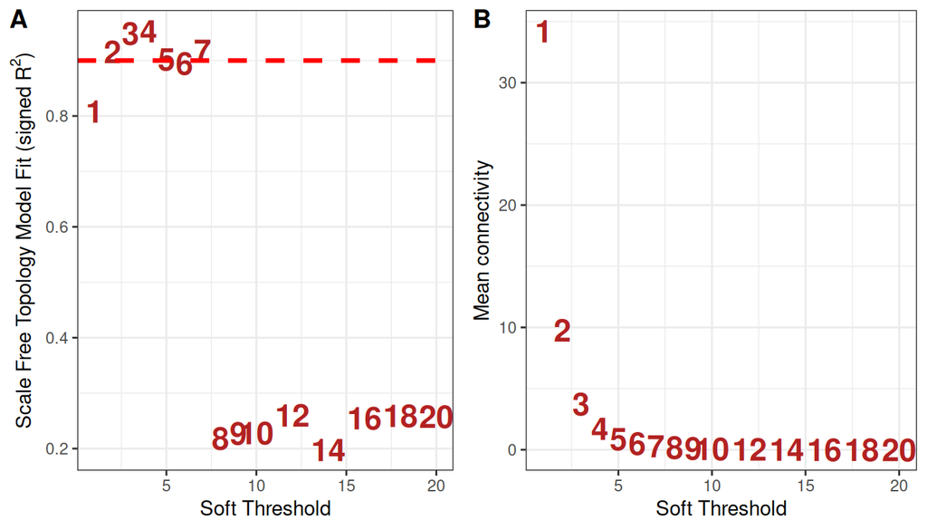

```r
ggarrange( p1, p2, ncol = 2, labels = c("A", "B"))
```

```r
# Choose a set of soft-thresholding powers
# powers = c(c(1:10), seq(from = 12, to=20, by=2))
powers = c(c(1:10), seq(from = 12, to=100, by=2))
# Call the network topology analysis function
enableWGCNAThreads(nThreads = 2)
```

```
## Allowing parallel execution with up to 2 working processes.
```

```r
sft = pickSoftThreshold(datExpr, powerVector = powers, verbose = 0)
```

```
##    Power SFT.R.sq slope truncated.R.sq  mean.k. median.k.   max.k.
## 1      1    0.809 -1.14        0.76900 3.42e+01  3.16e+01 6.16e+01
## 2      2    0.916 -1.05        0.89200 9.78e+00  7.29e+00 2.72e+01
## 3      3    0.949 -1.13        0.93500 3.75e+00  2.23e+00 1.51e+01
## 4      4    0.953 -1.15        0.95000 1.73e+00  7.77e-01 9.34e+00
## 5      5    0.903 -1.26        0.90600 9.05e-01  3.10e-01 6.20e+00
## 6      6    0.895 -1.26        0.90800 5.15e-01  1.26e-01 4.31e+00
## 7      7    0.918 -1.30        0.93400 3.12e-01  6.01e-02 3.11e+00
## 8      8    0.219 -2.20        0.03560 1.99e-01  2.83e-02 2.30e+00
## 9      9    0.228 -2.12        0.05730 1.32e-01  1.41e-02 1.73e+00
## 10    10    0.228 -2.04        0.06160 9.03e-02  7.22e-03 1.33e+00
## 11    12    0.260 -2.07        0.17500 4.58e-02  1.74e-03 8.19e-01
## 12    14    0.198 -2.30       -0.01870 2.51e-02  4.17e-04 5.26e-01
## 13    16    0.255 -2.82        0.08560 1.47e-02  1.03e-04 3.48e-01
## 14    18    0.260 -1.83        0.16500 8.93e-03  2.71e-05 2.36e-01
```

[output cut: 41 more lines]

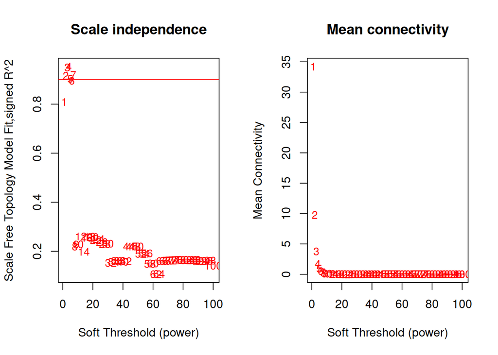

```r
# Plot the results:
#sizeGrWindow(9, 5)
par(mfrow = c(1,2))
cex1 = 0.9
# Scale-free topology fit index as a function of the soft-thresholding power
plot(sft$fitIndices[,1], -sign(sft$fitIndices[,3])*sft$fitIndices[,2],
xlab="Soft Threshold (power)",ylab="Scale Free Topology Model Fit,signed R^2",type="n",
main = paste("Scale independence"));
text(sft$fitIndices[,1], -sign(sft$fitIndices[,3])*sft$fitIndices[,2],
labels=powers,cex=cex1,col="red");
# this line corresponds to using an R^2 cut-off of h
abline(h=0.90,col="red")
# Mean connectivity as a function of the soft-thresholding power
plot(sft$fitIndices[,1], sft$fitIndices[,5],
xlab="Soft Threshold (power)",ylab="Mean Connectivity", type="n",
main = paste("Mean connectivity"))
text(sft$fitIndices[,1], sft$fitIndices[,5], labels=powers, cex=cex1,col="red")
```

```r
par(mfrow = c(1,1))
```